# Multivariate Regression Examples

Katherine Shim

October 30, 2018

### Multivariate regression example1

swiss dataset: Standardized fertility measure and socio-economic indicators for each of 47 French-speaking provinces of Switzerland at about 1888.

```
##                    Estimate  Std. Error   t value     Pr(>|t|)
## (Intercept)      66.9151817 10.70603759  6.250229 1.906051e-07
## Agriculture      -0.1721140  0.07030392 -2.448142 1.872715e-02
## Examination      -0.2580082  0.25387820 -1.016268 3.154617e-01
## Education        -0.8709401  0.18302860 -4.758492 2.430605e-05
## Catholic          0.1041153  0.03525785  2.952969 5.190079e-03
## Infant.Mortality  1.0770481  0.38171965  2.821568 7.335715e-03
```

The interpretation is

- Agriculture is expressed in percentages (0 - 100)
- Estimated coefficient is -0.1721.
- Our models estimates an expected 0.17 decrease in standardized fertility for every 1% increase in percentage of males involved in agriculture in holding the remaining variables constant.
- The t-test for $H_0: \beta_{Agri} = 0$ versus $H_a: \beta_{Agri} \neq 0$ is significant as p-value is lowe than 0.05.
- Interestingly, the unadjusted estimate is

```r
summary(lm(Fertility ~ Agriculture, data = swiss))$coefficients
```

```
##               Estimate Std. Error   t value     Pr(>|t|)
## (Intercept) 60.3043752 4.25125562 14.185074 3.216304e-18
## Agriculture  0.1942017 0.07671176  2.531577 1.491720e-02
```

We can see the coefficient is quite different and this scenario also suggests statistical significance. This phenomenom is called Simson’s paradox.

### Multivariate regression example2

```r
n <- 100
x2 <- 1 : n
x1 <- .01 * x2 + runif(n, -.1, .1)
y = -x1 + x2 + rnorm(n, sd = .01)
summary(lm(y ~ x1))$coef
```

```
##              Estimate Std. Error   t value     Pr(>|t|)
## (Intercept)  1.429912   1.073107  1.332497 1.857869e-01
## x1          95.129317   1.819928 52.270927 2.204852e-73
```

```r
summary(lm(y ~ x1 + x2))$coef
```

```
##                Estimate   Std. Error      t value      Pr(>|t|)
## (Intercept) -0.00218785 0.0022654316   -0.9657541  3.365689e-01
## x1          -1.01029775 0.0206719874  -48.8727923  3.947664e-70
## x2           1.00013572 0.0002113703 4731.6764778 6.156226e-262
```

We can see the first fit has positive x1 coefficient because it picked up the linear effect from x2. After the x2 linear effect got removed via adjustment x1 is having negative coefficient.  
However, we should be cautious of adding extra variables unnecessarily

### Multivariate regression on factor variables

**Linear regression on two level factor variables**: variables are binary variables

- Consider the linear model
  $$Y_i = \beta_0 + X_{i1} \beta_1 + \epsilon_{i}$$
  where each $X_{i1}$ is binary so that it is a 1 if measurement $i$ is in a group and 0 otherwise.
- Then for people in the group $E[Y_i] = \beta_0 + \beta_1$, and for people not in the group $E[Y_i] = \beta_0$
- Then, $\hat \beta_0 + \hat \beta_1$ is the mean for those in the group and $\hat \beta_0$ is the mean for those not in the group. So the estimated mean of the group will be the mean of those group.
- $\beta_1$ is interpretted as the increase or decrease in the mean comparing those in the group to those not.

**Linear regression on multi level factor variables** The example three factors are US political party affiliation; Republican, Democrat, Indepedent.

- $Y_i = \beta_0 + X_{i1} \beta_1 + X_{i2} \beta_2 + \epsilon_i$.
- $X_{i1}$ is 1 for Republicans and 0 otherwise. $X_{i2}$ is 1 for Democrats and 0 otherwise.
- We can omit $X_{i3}$ for Independent because we know it’s Independent when both $X_{i1}$ and $X_{i2}$ are zero.
- If $i$ is Republican $E[Y_i] = \beta_0 +\beta_1$
- If $i$ is Democrat $E[Y_i] = \beta_0 + \beta_2$.
- If $i$ is Independent $E[Y_i] = \beta_0$.
- $\beta_1$ compares Republicans to Independents.
- $\beta_2$ compares Democrats to Independents.
- $\beta_1 - \beta_2$ compares Republicans to Democrats.

### Multivariate regression example 3

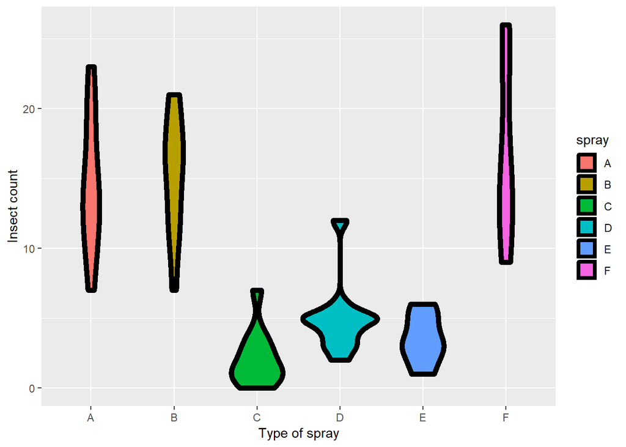

```r
data(InsectSprays)
g <- ggplot(data = InsectSprays, aes(y = count, x = spray, fill  = spray))
g <- g + geom_violin(colour = "black", size = 2)
g <- g + xlab("Type of spray") + ylab("Insect count")
g
```

R automatically choose spray A as reference. Other factor variables will be in comparison with sprayA.

```r
summary(lm(count~spray, data=InsectSprays))$coef
```

```
##                Estimate Std. Error    t value     Pr(>|t|)
## (Intercept)  14.5000000   1.132156 12.8074279 1.470512e-19
## sprayB        0.8333333   1.601110  0.5204724 6.044761e-01
## sprayC      -12.4166667   1.601110 -7.7550382 7.266893e-11
## sprayD       -9.5833333   1.601110 -5.9854322 9.816910e-08
## sprayE      -11.0000000   1.601110 -6.8702352 2.753922e-09
## sprayF        2.1666667   1.601110  1.3532281 1.805998e-01
```

- The intercept, 14.5 is the mean of counts in spray A group.
- The coefficient for spray B, 0.833, is the change in the mean between spray B and spray A. So the mean of the spray B is 15.33.

We can also hard code.

```r
summary(lm(count ~
             I(1 * (spray == 'B')) + I(1 * (spray == 'C')) +
             I(1 * (spray == 'D')) + I(1 * (spray == 'E')) +
             I(1 * (spray == 'F'))
           , data = InsectSprays))$coef
```

```
##                          Estimate Std. Error    t value     Pr(>|t|)
## (Intercept)            14.5000000   1.132156 12.8074279 1.470512e-19
## I(1 * (spray == "B"))   0.8333333   1.601110  0.5204724 6.044761e-01
## I(1 * (spray == "C")) -12.4166667   1.601110 -7.7550382 7.266893e-11
## I(1 * (spray == "D"))  -9.5833333   1.601110 -5.9854322 9.816910e-08
## I(1 * (spray == "E")) -11.0000000   1.601110 -6.8702352 2.753922e-09
## I(1 * (spray == "F"))   2.1666667   1.601110  1.3532281 1.805998e-01
```

If we include all the spray groups, R will omit the last factor variable automatically.

```r
summary(lm(count ~
   I(1 * (spray == 'B')) + I(1 * (spray == 'C')) +
   I(1 * (spray == 'D')) + I(1 * (spray == 'E')) +
   I(1 * (spray == 'F')) + I(1 * (spray == 'A')), data = InsectSprays))$coef
```

```
##                          Estimate Std. Error    t value     Pr(>|t|)
## (Intercept)            14.5000000   1.132156 12.8074279 1.470512e-19
## I(1 * (spray == "B"))   0.8333333   1.601110  0.5204724 6.044761e-01
## I(1 * (spray == "C")) -12.4166667   1.601110 -7.7550382 7.266893e-11
## I(1 * (spray == "D"))  -9.5833333   1.601110 -5.9854322 9.816910e-08
## I(1 * (spray == "E")) -11.0000000   1.601110 -6.8702352 2.753922e-09
## I(1 * (spray == "F"))   2.1666667   1.601110  1.3532281 1.805998e-01
```

Omit the intercept if you want mean of each group as its coefficient.

```r
summary(lm(count ~ spray - 1, data = InsectSprays))$coef
```

```
##         Estimate Std. Error   t value     Pr(>|t|)
## sprayA 14.500000   1.132156 12.807428 1.470512e-19
## sprayB 15.333333   1.132156 13.543487 1.001994e-20
## sprayC  2.083333   1.132156  1.840148 7.024334e-02
## sprayD  4.916667   1.132156  4.342749 4.953047e-05
## sprayE  3.500000   1.132156  3.091448 2.916794e-03
## sprayF 16.666667   1.132156 14.721181 1.573471e-22
```

```r
#We can see that the coefficients are exactly equal to the mean of the counts of each spray group
summarise(group_by(InsectSprays, spray), mn = mean(count))
```

```
## # A tibble: 6 x 2
##   spray    mn
##   <fct> <dbl>
## 1 A     14.5
## 2 B     15.3
## 3 C      2.08
## 4 D      4.92
## 5 E      3.5
## 6 F     16.7
```

You can reorder the levels using relevel function. In the example below, now spray C will be used as reference group.

```r
spray2 <- relevel(InsectSprays$spray, "C")
summary(lm(count~spray2, data=InsectSprays))$coef
```

```
##              Estimate Std. Error  t value     Pr(>|t|)
## (Intercept)  2.083333   1.132156 1.840148 7.024334e-02
## spray2A     12.416667   1.601110 7.755038 7.266893e-11
## spray2B     13.250000   1.601110 8.275511 8.509776e-12
## spray2D      2.833333   1.601110 1.769606 8.141205e-02
## spray2E      1.416667   1.601110 0.884803 3.794750e-01
## spray2F     14.583333   1.601110 9.108266 2.794343e-13
```

### Multivariate regression on mix of factor and cont’ variables

In this examplle, factor variable is CatholicBin and cont’ variable is Agriculture. We will fit multiple models.

```r
swiss <- mutate(swiss, CatholicBin = 1 * (Catholic > 50))
```

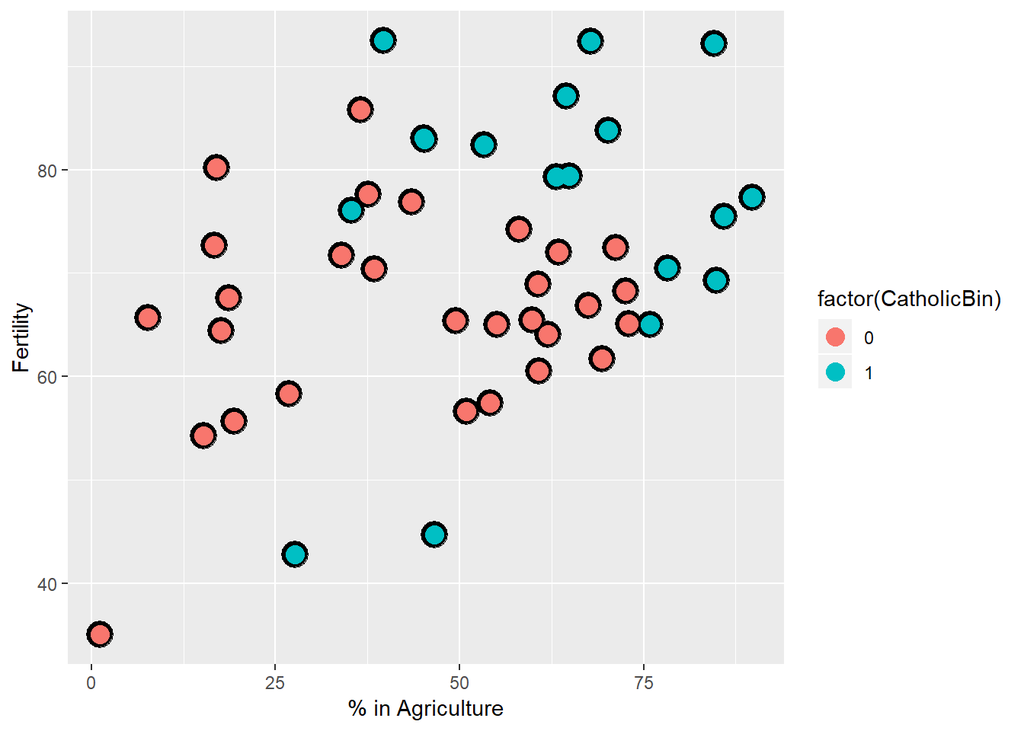

```r
g = ggplot(swiss, aes(x = Agriculture, y = Fertility, colour = factor(CatholicBin)))
g = g + geom_point(size = 6, colour = "black") + geom_point(size = 4)
g = g + xlab("% in Agriculture") + ylab("Fertility")
g
```

**Model1: Use only Agriculture as covariate**

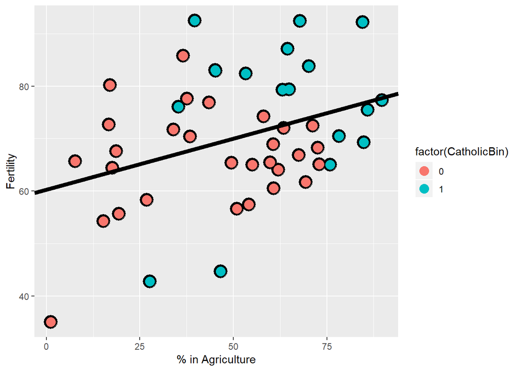

```r
fit <- lm(Fertility ~ Agriculture, data = swiss)
g1 <- g
g1 <- g1 + geom_abline(intercept = coef(fit)[1], slope = coef(fit)[2], size = 2)
g1
```

**Model2: Use Agriculture and CatholicBin as covariates**

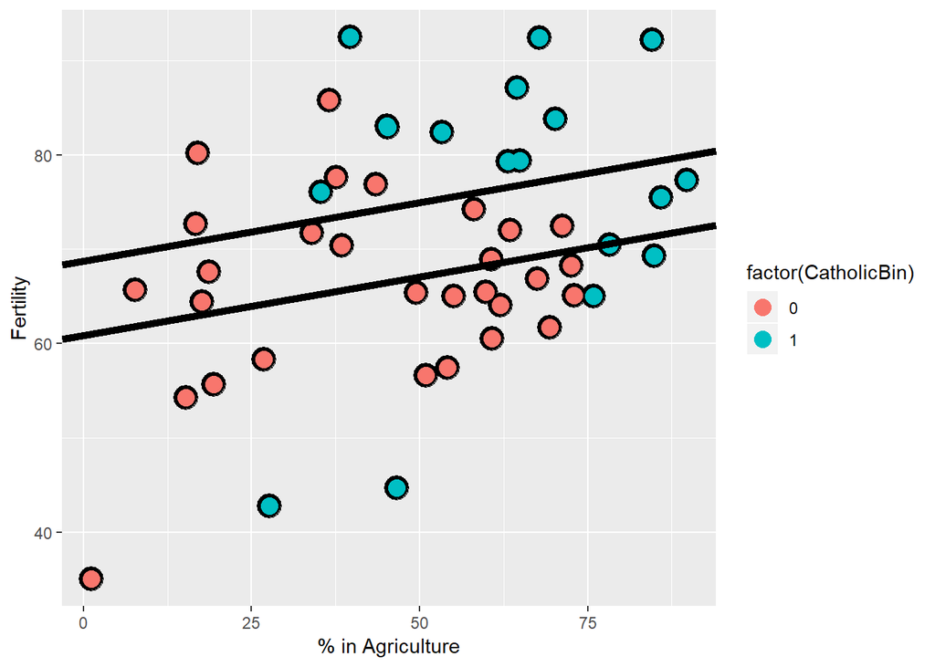

```r
fit2 <- lm(Fertility ~ Agriculture + factor(CatholicBin), data = swiss)
g2 <- g
#The first line is when CatholicBin=0
g2 <- g2 + geom_abline(intercept = coef(fit2)[1], slope = coef(fit2)[2], size = 2)
#The second line is when CatholicBin=1
g2 <- g2 + geom_abline(intercept = coef(fit2)[1] + coef(fit2)[3], slope = coef(fit2)[2], size = 2)
# The intercepts are different but slopes are the same
g2
```

**Model3: Use Agriculture and CatholicBin, and their interaction as covariates**

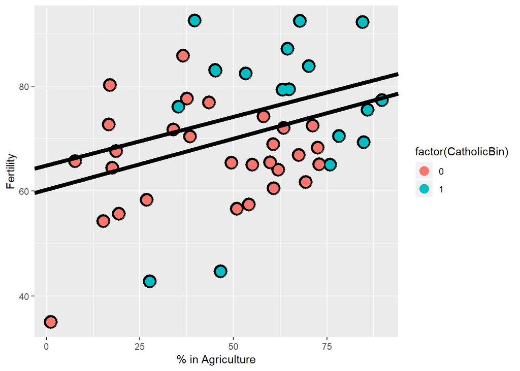

```r
fit3 <- lm(Fertility ~ Agriculture * factor(CatholicBin), data = swiss)
g3 <- g
#The first line is when CatholicBin=0
g3 <- g1 + geom_abline(intercept = coef(fit3)[1], slope = coef(fit3)[2], size = 2)
#The second line is when CatholicBin=1
g3 <- g1 + geom_abline(intercept = coef(fit3)[1] + coef(fit3)[3],
                          slope = coef(fit3)[2] + coef(fit3)[4], size = 2)
#Both intercepts and slopes are different
g3
```

- The intercept is for non catholic provinces
- Agriculture coeff is slope for non catholic provinces
- Intercept + factor(CatholicBin)1 coeffs will be intercept for catholic provinces
- Agriculture + Agriculture:factor(CatholicBin)1 coeffs will be slope for catholic provinces